# Machine Learning Algorithms From Scratch Using R

Lance Wrobel

In this R notebook, I implement some common machine learning algorithms and statistical models from scratch and without use of the R machine learning packages. This work was done for learning purposes. So far I implemented kmeans and multiple linear regession (exact solution and by using gradient descent).

I will use the following libraries throughout this notebook. For purposes other than plotting, Base R is mostly used.

```r
library(dplyr)
```

```r
library(magrittr)
library(ggplot2)
```

The first algorithm I implement is the kmeans algorithm.

```r
init_random_centroids <- function(df, k){

      df_dim <- ncol(df)
      df_numpoints <- nrow(df)
      centroid_matrix <- matrix(nrow = k, ncol = df_dim) # initialize matrix

      dimension_bounds_matrix <- matrix(nrow = df_dim, ncol = 2) # min and max across each dimension of the data frame df

      for(i in 1:df_dim){

          dimension_bounds_matrix[i,1] <- min(df[,i])
          dimension_bounds_matrix[i,2] <- max(df[,i])

      }
      # generate random values between the min and max of each dimension of df
      random_numbers <- function(x){runif(1, min=dimension_bounds_matrix[x,1], max=dimension_bounds_matrix[x,2])}

      generate_centroid_point <- function(x){sapply(1:df_dim, random_numbers)}

      centroid_matrix <- as.matrix(t(sapply(1:k, generate_centroid_point))) # create k random sets of numbers between min and (max-1)


      return(centroid_matrix)
}

assign_to_clusters <- function(df,k,centroid_matrix){

      df_dim <- ncol(df)
      df_numpoints <- nrow(df)

      cluster_ids <- vector(length = df_numpoints)
      distances_vector <- vector(length = k) # this vector contains the distances between the current point and each cluster center

      for(i in 1:df_numpoints){

          distances_to_point <- function(x){dist(rbind(df[i,], centroid_matrix[x,]))}

          distances_vector <-  sapply(1:k, distances_to_point)

          cluster_ids[i] <- which.min(distances_vector) # index of the vector with the smallest value
      }

      return(cluster_ids)
}
update_centroids <- function(df,centroid_matrix,cluster_ids){

      df_dim <- ncol(df)
      df_numpoints <- nrow(df)

      df_with_ids <- cbind(df,cluster_ids) # we want the cluster ids attached to the data frame

      # each coordinate of the centroids is the mean of that coordinate value across the cluster
      updated_centroid_matrix <- df_with_ids %>% group_by(cluster_ids) %>% summarise_all(mean) %>% select(-cluster_ids)

      return(as.matrix(updated_centroid_matrix))
}

kmeans_clustering <- function(df, k, max_iter){

      df_dim <- ncol(df)
      df_numpoints <- nrow(df)

      centroid_matrix <- init_random_centroids(df,k) # Chose k random centroids within domain of dataset to start

      cluster_ids <- assign_to_clusters(df,k,centroid_matrix) # initially assign each datapoint to nearest cluster center

      count_iter <- 0
      while(count_iter < max_iter) {

        centroid_matrix <- update_centroids(df,centroid_matrix,cluster_ids) # update centroids to reflect new assignment of cluster ids

        cluster_ids <- assign_to_clusters(df,k,centroid_matrix) # assign points to new clusters

        count_iter <- count_iter + 1
      }

      return(cbind(df,cluster_ids))
}
```

Next I test the kmeans algorithm using the built-in iris dataset.

```r
clustered_data<- kmeans_clustering(iris[,2:3],3,20)
```

Then I visualize the results of kmeans to get a sense of how well it works.

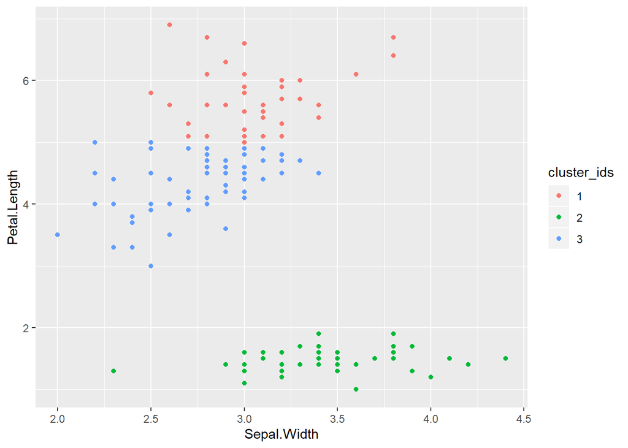

```r
clustered_data$cluster_ids <- as.factor(clustered_data$cluster_ids) # needs to be a factor so ggplot works

ggplot(data=clustered_data, aes(x=Sepal.Width, y=Petal.Length,  color=cluster_ids))+geom_point()
```

Below I implement multiple linear regression from scratch. The formula I used for the beta coefficients can be shown with calculus to be the optimal solution to the problem of minimizing the sum of squared residuals.

```r
calculate_beta_vector<-function(train_x, train_y){

      beta_vector <- solve(t(train_x) %*% train_x) %*% t(train_x) %*% train_y # formula for optimal betas, can be found by calculus

      return(beta_vector)
}

predict_glr <- function(test_x, train_x, train_y){

      train_x <- as.matrix(train_x) # make the training and testing data matrices in order to do matrix multiplication
      train_y <- as.matrix(train_y)
      test_x <- as.matrix(test_x)

      num_points_train <- nrow(train_x)
      num_points_test <- nrow(test_x)

      test_x <- cbind(rep(1,num_points_test),test_x) # bind vector of ones for intercept
      train_x <- cbind(rep(1,num_points_train),train_x) # bind vector of ones for intercept

      beta_vector <- calculate_beta_vector(train_x, train_y)

      predicted_y <- test_x %*% beta_vector

      return(list(predicted_y, beta_vector))
}
```

To test my implementation, I use an NBA dataset of player statistics and I look at the relationship between minutes played by the player and the number of field goals the player made. I used these variables since this relationship is mostly linear.

Below I test the multiple linear regression by plotting the actual field goal values and the predicted values on the same plot.

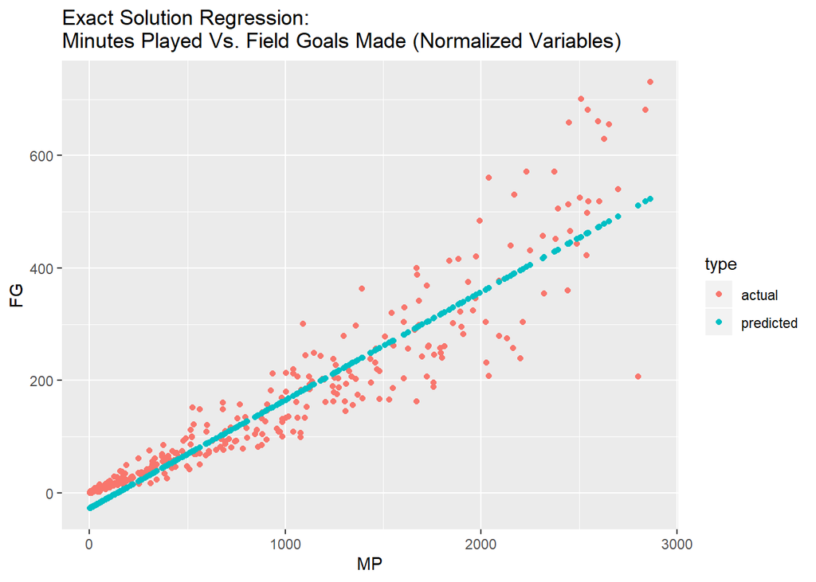

```r
nba_data <- read.csv("NBA_Stats_Analysis.csv")

nba_data_subset <- nba_data[,c("MP","Age","FG")]

train <-  as.data.frame(na.omit(nba_data_subset[1:400,]))
test <-  as.data.frame(na.omit(nba_data_subset[401:735,]))

train_x <- train$MP
test_x <- test$MP

train_y <- train$FG
test_y <- test$FG

glr_results <- predict_glr(as.data.frame(test_x), as.data.frame(train_x), as.data.frame(train_y))

predicted_y <- glr_results[[1]]

n <- nrow(test)

predicted <- test
actual <- test

actual$type <- rep("actual",n)
predicted$type <- rep("predicted",n)

predicted$FG <- predicted_y

data_to_plot<- as.data.frame(rbind(actual,predicted))

ggplot(data_to_plot, aes(MP,FG, color=type))+geom_point() + ggtitle("Exact Solution Regression: \nMinutes Played Vs. Field Goals Made (Normalized Variables)")
```

The r-squared for the regression model is calculated below.

```r
test_copy <- test

test_copy$predicted_y <- predicted_y

y_mean <- mean(test_copy$FG)

ss_total <- sum((test_copy$FG - y_mean)^2)
ss_res <- sum((predicted_y - test_copy$FG)^2)

r_2 <- 1 - ss_res/ss_total

cat("R^2: ", r_2)
```

```
## R^2:  0.8652234
```

I will next look at solving the multiple linear regression problem using a gradient descent approach.

```r
update_betas <- function(beta_vector, predicted_y, train_y, train_x, alpha){

        num_points <- nrow(train_x)
        num_var <- ncol(train_x)

        beta_vector[1] <- beta_vector[1] - alpha*(1/(num_points))*sum((predicted_y - train_y))

        temp <- function(x){(alpha*(1/(num_points))*sum((predicted_y - train_y)*x))}

        beta_vector[2:(num_var)] <- beta_vector[2:(num_var)] - sapply(as.data.frame(train_x[,2:(num_var)]), temp)

        return(beta_vector)
        }

grad_descent_lr <- function(train_x, train_y, max_iter=300, alpha=0.01, error_threshold=0.1){

      num_points <- nrow(train_x)
      num_var <- ncol(train_x)

      train_x <- as.matrix(cbind(rep(1,num_points),train_x)) # bind a column of ones to the training data to account for the intercept in regression

      beta_vector <- as.matrix(rnorm(num_var+1, mean=1, sd=0.5)) # num_var + 1 which includes y-int as first entry

      beta_matrix <- matrix(nrow = max_iter, ncol = (num_var+1)) # keep all previous beta vectors in a matrix to visualize convergence path after

      error_vector <- rep(0,max_iter)
      num_iter <- 0
      error_diff <- error_threshold + 0.001 # fix this later, error_diff should really start at zero

      sum_of_squared_error <- 0
      while (num_iter < max_iter && error_diff > error_threshold){

        prev_sum_of_squared_error <- sum_of_squared_error

        predicted_y <- t(beta_vector) %*% t(train_x)

        prev_beta_vector <- beta_vector # store beta vector before update to compute the error between the previous and updated beta vectors

        beta_vector <- update_betas(beta_vector, predicted_y, train_y, train_x, alpha) # update betas using formula found in algorithm

        sum_of_squared_error <- sum((predicted_y - train_y)^2) # sum of squared error, used to measure convergence of the algorithm

        # error diff is used as a measure of convergence, error_diff is very small once the algorithm converges
        error_diff <- abs(prev_sum_of_squared_error - sum_of_squared_error)

        beta_matrix[num_iter+1,] <-  beta_vector
        error_vector[num_iter+1] <- sum_of_squared_error

        num_iter <- num_iter + 1
      }
      return(list(beta_vector, sum_of_squared_error,num_iter, beta_matrix, error_vector))
}

predict_gd_lr <- function(test_x, beta_vector){

        test_x <- as.matrix(test_x) # needed for matrix multiplication

        num_points <- nrow(test_x)

        test_x <- cbind(rep(1, num_points), test_x) # bind vector of ones for intercept

        predicted_y <- test_x %*% beta_vector

        return(predicted_y)
}
```

Below I visually test the gradient descent approach to regression by using the same NBA data I used before.

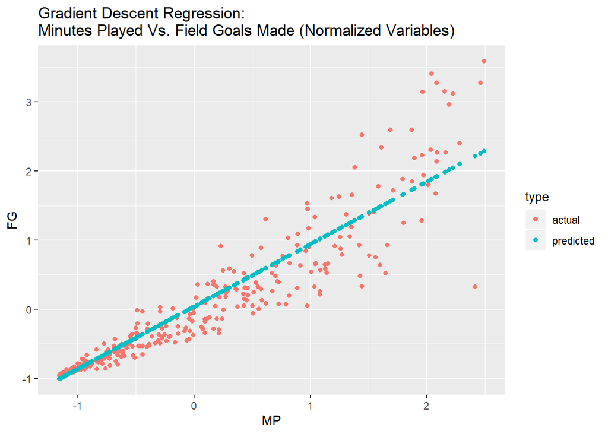

```r
# normalize the NBA data first using the Z score method
train_NormZ <- as.data.frame(scale(train))
test_NormZ <- as.data.frame(scale(test))

# run stochastic gradient descent, I needed to cast the normalized training data to data frames to avoid some issues
grad_descent_results <- grad_descent_lr(train_x=as.data.frame(train_NormZ$MP), train_y=as.data.frame(train_NormZ$FG), max_iter=300, alpha=0.01, error_threshold=0.001)

beta_vector <- grad_descent_results[[1]]

test_x <- as.data.frame(test_NormZ$MP) # predictor matrix

predicted_y <- predict_gd_lr(test_x, beta_vector)

actual_normZ <- test_NormZ # make a copy of the normalized test data to put actual data (done for plotting with ggplot purposes)

n <- nrow(actual_normZ)

predicted_normZ <- actual_normZ

actual_normZ$type <- rep("actual",n)
predicted_normZ$type <- rep("predicted",n)

predicted_normZ$FG <- predicted_y

data_to_plot <- as.data.frame(rbind(actual_normZ, predicted_normZ))

ggplot(data_to_plot, aes(MP,FG, color=type)) + geom_point() + ggtitle("Gradient Descent Regression: \nMinutes Played Vs. Field Goals Made (Normalized Variables)")
```

I will next visualize how the sum of squared error changed after each iteration when the learning rate alpha is set to 0.01.

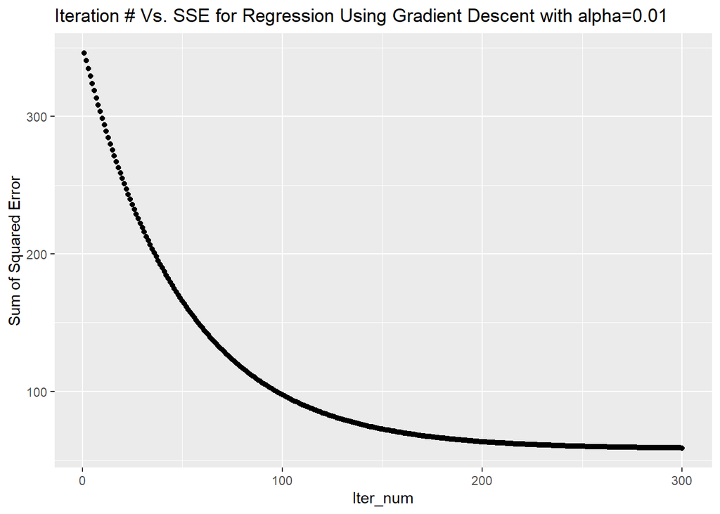

```r
max_iter <- 300

betas_df <- as.data.frame(grad_descent_results[[4]])
sse_vector <- as.data.frame(grad_descent_results[[5]])

betas_error_df <- as.data.frame(cbind(seq(max_iter),betas_df, sse_vector))

colnames(betas_error_df) <- c("Iter_num","beta_0", "beta_1", "error")

ggplot(betas_error_df, aes(x=Iter_num, y=error))+geom_point()+ggtitle("Iteration # Vs. SSE for Regression Using Gradient Descent with alpha=0.01") + ylab("Sum of Squared Error")
```